# Replication

Ainsley Lotito

2026-02-06

# Replication of tables/figures from Vaca et al. (2011)

## Table 1

To replicate the table, we need to:

1. subset to males 15-24
2. collapse years 1999-2006
3. use population data from 1999-2006 to calculate overall rates

```
## # A tibble: 6 × 4
##   cod           black               hispanic            white
##   <fct>         <chr>               <chr>               <chr>
## 1 homicide      136.7 (130.6–143.1) 38.4 (37.1–39.6)    7.0 (6.4–7.6)
## 2 mvc           24.7 (22.1–27.5)    26.2 (25.2–27.3)    28.4 (27.2–29.6)
## 3 suicide       8.3 (6.8–10.0)      8.5 (7.9–9.2)       15.5 (14.6–16.4)
## 4 other_injury  12.6 (10.8–14.7)    10.6 (9.9–11.3)     14.6 (13.8–15.5)
## 5 other_disease 39.3 (36.1–42.8)    19.7 (18.8–20.7)    22.1 (21.1–23.2)
## 6 all_cause     230.6 (222.6–238.9) 107.4 (105.3–109.6) 91.6 (89.5–93.8)
```

## Figure 1

Next, we are going to replicate Figure 1, which is “Male all cause mortality rate ratios comparing Latino and non-Latino black mortality to non-Latino white mortality, by 5 year age groups with 95% CI, California, 1999-2006.

We will need to

**1. subset to males, all-cause only, retaining age groups, summing deaths for years 1999:2006**

**2. use population data from 1999-2006 to calculate overall rates by age groups**

**3. Calculate rate ratios with NH white as reference group** For each 5-year age group, we first calculate all-cause mortality rates for each race/ethnicity as the total number of deaths from 1999–2006 divided by the corresponding summed population for the same period. Rates are expressed per 100,000 population. Within each age group, we then calculate mortality rate ratios (RRs) by dividing the mortality rate for Latino males and non-Latino Black males by the mortality rate for non-Latino White males (reference group). Ninety-five percent confidence intervals for the rate ratios are estimated using a Poisson approximation based on the number of deaths in the comparison and reference groups.

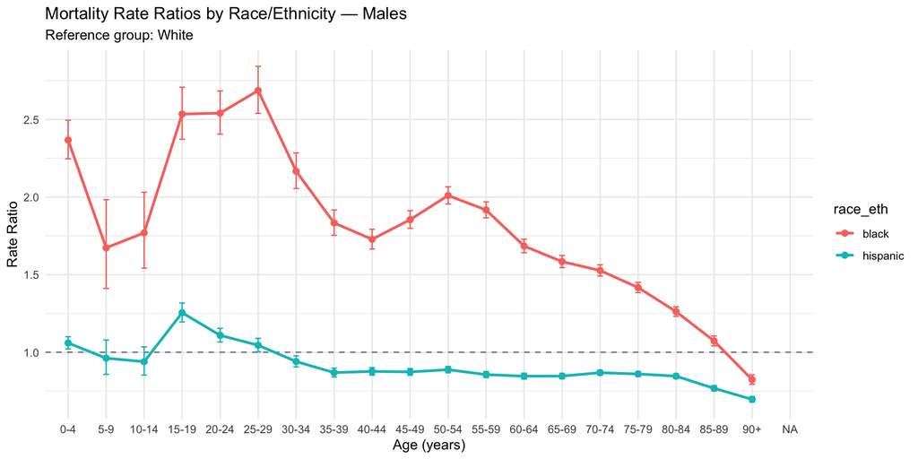

## Figure 2

Next, we are going to replicate Figure 2, which is “Female all cause mortality rate ratios comparing Latino and non-Latino black mortality to non-Latino white mortality, by 5 year age groups with 95% CI, California, 1999-2006.

We will need to replicate the previous steps, except subsetting to **females** instead of males.

**1. Subset to females, all-cause only, retaining age groups, summing deaths for years 1999:2006**

**2. Use population data from 1999-2006 to calculate overall rates by age groups**

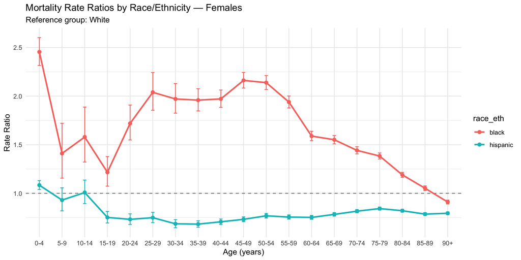

## Figure 3

Next, we are going to replicate Figure 3, which is “Male homicide mortality rate ratios comparing Latino and non-Latino black mortality to non-Latino white mortality, by 5 year age groups with 95% CI, California, 1999-2006 (Overlapping 95% CI for age group 80 years and older not shown.)”.

We will start by selecting just homicide data, then replicate previous steps.

**2. Use population data from 1999-2006 to calculate overall rates by age groups**

**3. Calculate death rates**

[figure not shown]

This plot differs a little bit from the one we are replicating, just because it excludes the white data that is missing (it is likely that these values didn’t populate in the CDC query due to being less than 10 for the years in question). It also excludes deaths for ages 70+, most likely for the same exact reason. Looking at the figure in Vaca et al, it appears as though there are some homicides among Blacks at age 90+ and maybe for Hispanics, but our data doesn’t populate this. This difference is likely negligible, since most of the important trends may be observed at younger age groups.

## Figure 4

Next, we are going to replicate Figure 4, which is “Male mortality rate ratios for all causes except homicide, comparing Latino and non-Latino black mortality to non-Latino white mortality, by 5 year age groups with 95% CI, California, 1999-2006”.

We will start by calculating all cause - homicides, then replicate previous steps.

**1. Calculate all-case deaths - homicides**

**2. Subset to male, subtract homicides from all cause, retaining age groups, summing deaths for years 1999:2006**

**3. Use population data from 1999-2006 to calculate overall rates by age groups**

**4. Calculate rate ratios with NH white as reference group**

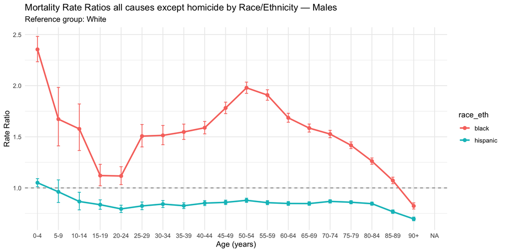

## Figure 5

Next, we are going to replicate Figure 5, which is “Homicide mortality rates, among males 15-24 years of age, comparing Latino, non-Latino black, and non-Latino white, by year with 95% CI, California 1999-2006”.

We will start by selecting homicides among males 15-24, then replicate previous steps.

**1. Subset to males aged 15-24, homicides only, summing deaths for years 1999:2006**

**2. Use population data from 1999-2006 to calculate overall rates by age groups**

**3. Calculate death rates**

[figure not shown]

## Figure 6

This figure is comparing death rates for motor vehicle crashes by age groups (“Male motor vehicle crash mortality rates, comparing Latino, non-Latino black, and non-Latino white, 5 year age groups with 95% CI, California 1999-2006. (Points are offset to show CI; upper CI above 50/100,000 not shown).”)

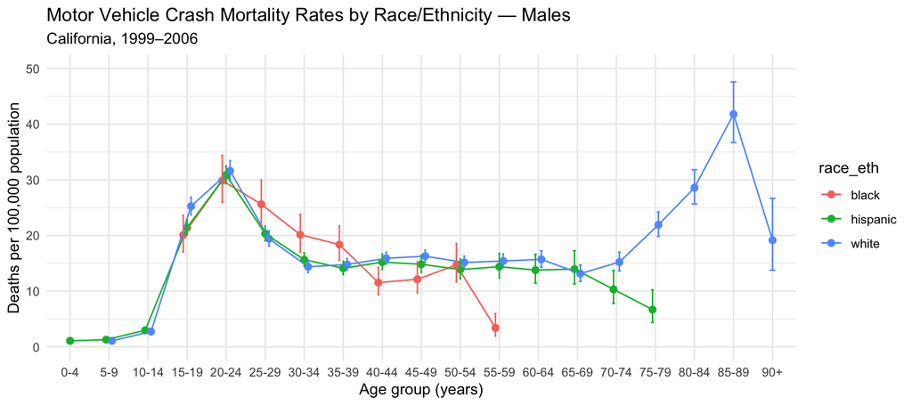

As you may notice, we are missing data for some age groups, more prominently surrounding NH Blacks that are less than 15 years old and over 60 years old. I ran the following check, but it appears that similar to the other plot, we just don’t have mvc data for these age groups. We likely observe this because our cdc query just doesn’t populate due to insufficient cell size. However, this is a bit surprising since MVC deaths appear pretty large among Non-Latino Blacks in Vaca et al (2011). One thing we might try is importing another dataset from cdc wonder, this time stratifying by 10 year age groups. For now, we will continue on…

```
## [1] age_group  year       sex        race_eth   deaths     crude.rate cod
## <0 rows> (or 0-length row.names)
```

## Figure 7

This figure also displays motor vehicle crash mortality rates, this time only including ages 15-24, comparing the rates for each race/ethnicity over each year in the study period.

```
## # A tibble: 24 × 8
##     year race_eth deaths population     rate rate_per_100k rate_lcl rate_ucl
##    <int> <chr>     <int>      <dbl>    <dbl>         <dbl>    <dbl>    <dbl>
##  1  2002 white       306    936374. 0.000327          32.7     29.1     36.6
##  2  2006 hispanic    383   1205388. 0.000318          31.8     28.7     35.1
##  3  2005 black        55    175626. 0.000313          31.3     23.6     40.8
##  4  2003 white       292    958274. 0.000305          30.5     27.1     34.2
##  5  2002 hispanic    328   1123903. 0.000292          29.2     26.1     32.5
##  6  2004 white       281    975009. 0.000288          28.8     25.5     32.4
##  7  2001 white       260    918314. 0.000283          28.3     25.0     32.0
##  8  2006 white       280    990066. 0.000283          28.3     25.1     31.8
##  9  2005 hispanic    333   1179606. 0.000282          28.2     25.3     31.4
## 10  2003 hispanic    317   1139515. 0.000278          27.8     24.8     31.1
## # ℹ 14 more rows
```

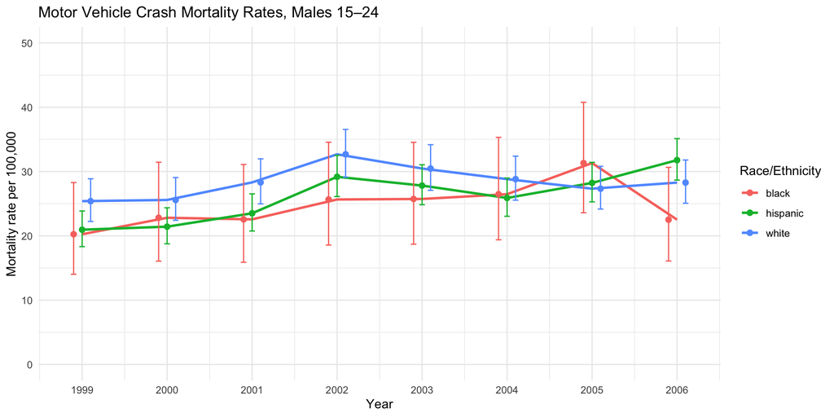

```
## # A tibble: 45 × 8
##     year race_eth deaths population     rate rate_per_100k rate_lcl rate_ucl
##    <int> <chr>     <int>      <dbl>    <dbl>         <dbl>    <dbl>    <dbl>
##  1  2018 black        36     84377  0.000427          42.7     29.9     59.1
##  2  2020 black        56    144493  0.000388          38.8     29.3     50.3
##  3  2016 black        32     90849  0.000352          35.2     24.1     49.7
##  4  2006 hispanic    383   1205388. 0.000318          31.8     28.7     35.1
##  5  2007 hispanic    362   1231596. 0.000294          29.4     26.4     32.6
##  6  2006 white       280    990066. 0.000283          28.3     25.1     31.8
##  7  2007 white       279    991319. 0.000281          28.1     24.9     31.6
##  8  2017 black        42    161591  0.000260          26.0     18.7     35.1
##  9  2008 white       234    986376. 0.000237          23.7     20.8     27.0
## 10  2011 black        21     89763  0.000234          23.4     14.5     35.8
## # ℹ 35 more rows
```

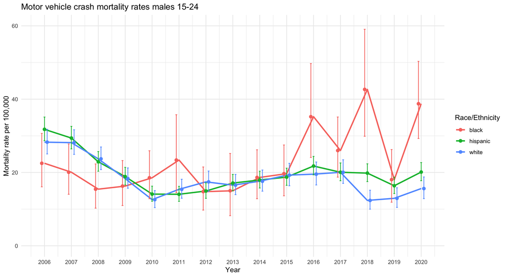